# CS559: Homework #2

### Due:10/8/2021 Friday 11:59 PM

- Change the file name as YourName_F21_CS559_HW2
- Submit the assignment in `ipynb` and `html` formats.
  - You can export the notebook in HTML.
  - Do not compress your files. Please submit files individually.
- All work must be your own and must not be shared with other classmates.
  - Collaboration with classmates or getting help by any people is not acceptable.
  - For impletementation problems, do not copy algorithms from internet.

### Problem 1 - Linear Regression [35 pts]

1-a. Consider a data set in which each data point $t_n$ is associated with a weighting factor $r_n>0$, so that the sum of squares error function becomes

$${\large E_D(\vec{w})=\frac{1}{2}\sum_{n=1}^Nr_n\big(t_n-\vec{w}^T\vec{x}_n\big)^2}$$

Find an expression for the solution $w^*$ that minimizes this error function. [5 pts]

Given that the solution of minimizing OLS is: $${\hat{\beta}=(x^tx)^{-1}x^tt}$$

The solution for minimizing WLS is: $${\hat{\beta}=(x^trx)^{-1}x^trt}$$

1-b. Implement a function called, `my_error(data,r_n)`, that estimates the error using the error function, $E_D(\vec{w})$, from 1-a. The task to implement a function to estimates the optimized $vec{w}$ and demonstrates the behavior of error at different weighting factor, $r_n$, values. The function return a list of $\vec{w}$, $r_n$, and error. Do not use any other modules except `numpy`. [10 pts]

```python
import numpy as np

def calcWvec(data, r_n):
    x = data.iloc[:, 0:-1]
    y = data.iloc[:,-1]
    size = y.size
    ones = np.array([1]*size).reshape(-1,1)
    x_m = np.mat(np.append(ones, x.to_numpy(),1))
    y_m = np.mat(y.to_numpy().reshape(-1,1))
    #make diaganol of r
    w = np.mat(np.diagflat(r_n))

    B = (x_m.T*w*x_m).I * x_m.T  * w * y_m
    return B.T

def my_error(data, r_n):
    x = data.iloc[:, 0:-1]
    y = data.iloc[:,-1]
    size = y.size
    ones = np.array([1]*size).reshape(-1,1)
    x_m = np.mat(np.append(ones, x.to_numpy(),1))
    y_m = np.mat(y.to_numpy().reshape(-1,1))
    w = calcWvec(data, r_n)

    e = 0
    for i in range(len(y_m)):
        t_n = y_m[i]
        x_n = x_m[i]
        est = w * x_n.T
        e_n = r_n[i] * (t_n - est)**2
        e += e_n
    return e/2

### my_LR starts here
def my_LR(data,r_n):
    w = []
    error = []
    for r in r_n:
        w.append(calcWvec(data, r))
        error.append(my_error(data, r))

    return w, error, r_n
```

1-c. Load the dataset, make a model using Linear Regression from sklearn.linear_model to predict the target `y` from a given dataset `HW2_LR.csv`. Students must do EDA and pre-processing the dataset before training the model. All pre-processing and EDA work must be explained and the weights and mean squared error value must be reported. Treat the whole dataset as a train set. [15 pts]

```python
from sklearn.linear_model import LinearRegression
from sklearn.metrics import mean_squared_error
import matplotlib.pyplot as plt

import pandas as pd
```

```python
df = pd.read_csv('./HW2_LR.csv')
df.head(5)
```

|  | a | b | c | d | k | y |
| --- | --- | --- | --- | --- | --- | --- |
| 0 | 70.40 | 611.72 | 2679.33 | -0.116531 | 0.408765 | -9.804385e+05 |
| 1 | 297.79 | 172.91 | 8986.70 | -0.668901 | 0.906781 | 1.343908e+06 |
| 2 | 213.93 | 423.22 | 1505.50 | -0.573668 | 0.862750 | -6.170783e+05 |
| 3 | 39.25 | 353.36 | 8332.22 | -0.144505 | 0.730970 | 2.070210e+06 |
| 4 | 5.95 | -174.07 | 3210.43 | -0.157336 | -0.175142 | -7.709453e+05 |

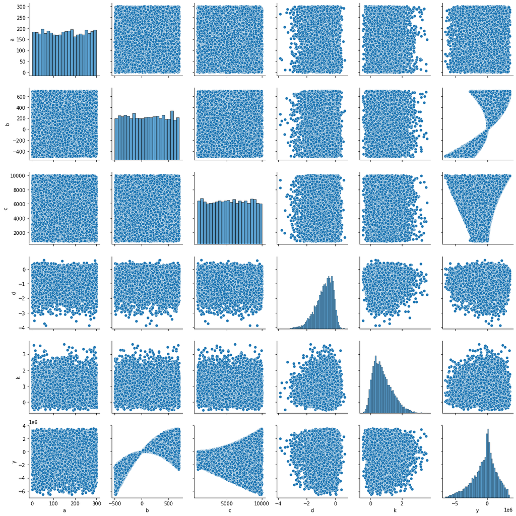

```python
### EDA stars here
import seaborn as sns

cols = ['a', 'b', 'c', 'd', 'k', 'y']
sns.pairplot(df[cols],size=2.5)
plt.tight_layout()
plt.show()
```

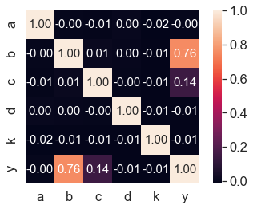

```python
import numpy as np

cm=np.corrcoef(df[cols].values.T)
sns.set(font_scale=1.5)
hm=sns.heatmap(cm,cbar=True,annot=True,square=True,fmt='.2f',annot_kws={'size':15},yticklabels=cols,xticklabels=cols)
plt.show()
```

Although 'b' does not have a normal distribution, it is the only feature to have a strong correlation with the target 'y'. Therefore, only the feature 'b' should be used in the linear regression model. None of the features have a strong correlation with the other features and should be combined.

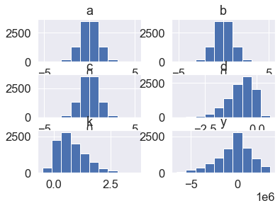

```python
### Pre-processing starts here

#Scale uniform distributions
from sklearn.preprocessing import QuantileTransformer
from sklearn.preprocessing import StandardScaler
uniform_df=df[['a', 'b', 'c']]
scaler = QuantileTransformer(output_distribution='normal')
df_scale= scaler.fit_transform(uniform_df)
df['a'] = df_scale[:,0].reshape(-1,1)
df['b'] = df_scale[:,1].reshape(-1,1)
df['c'] = df_scale[:,2].reshape(-1,1)
df.hist()
plt.show()
```

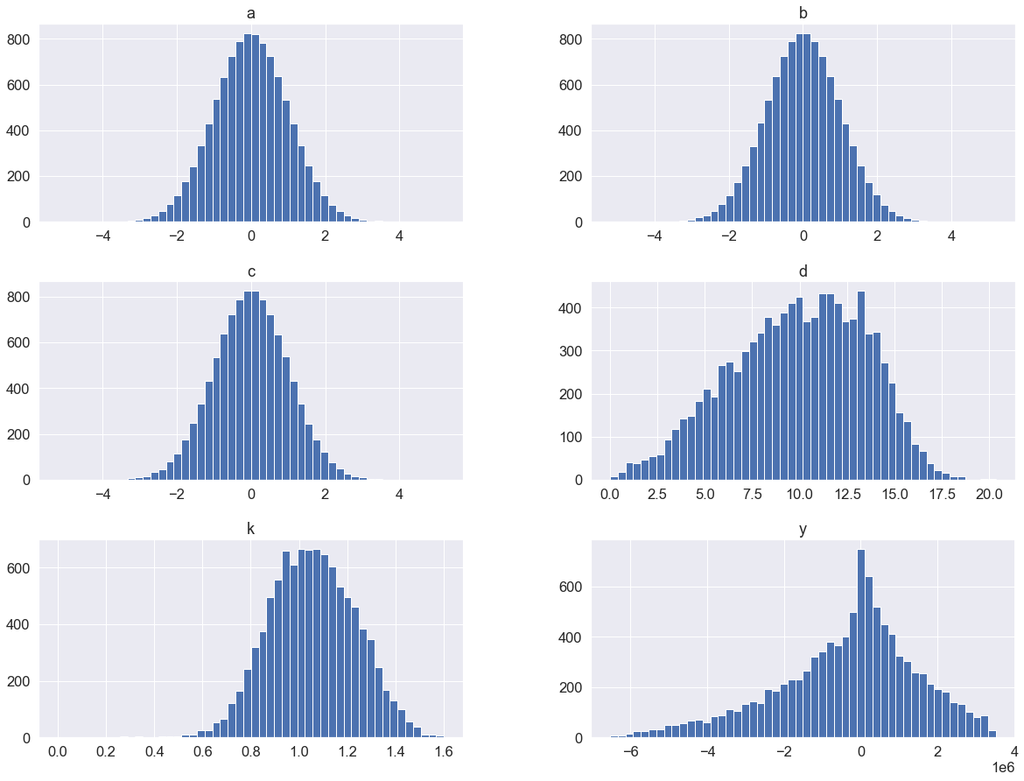

```python
#Scale skewed data
rskew_df=df[['k']]
#Shift distribution to be positive
rskew_df += np.abs(rskew_df.to_numpy().min())
rskew_df= np.power((rskew_df),1/3)
df['k'] = rskew_df

lskew_df=df[['d']]
#Shift distribution to be positive
lskew_df += np.abs(lskew_df.to_numpy().min())
lskew_df= np.power((lskew_df),2)
df['d'] = lskew_df

df.hist(bins=50, figsize=(20,15))
plt.show()
```

```python
#Finally scale normal distributions
from pandas.core.frame import DataFrame
scaler = StandardScaler()
scale = scaler.fit_transform(df)
f_df = DataFrame(scale, columns=['a','b','c','d','k','y'])
```

```python
X = f_df[['b']]
y = f_df[['y']]
### Linear Regression Modeling starts here
LR = LinearRegression()
LR.fit(X, y)

y_train_pred = LR.predict(X)
from sklearn.metrics import mean_squared_error
print('MSE train: %.3f' %(mean_squared_error(y,y_train_pred)))
#                                     mean_squared_error(y_test,y_test_pred)))
from sklearn.metrics import r2_score
print('R^2 train: %.3f' %(r2_score(y,y_train_pred)))
#                                     r2_score(y_test,y_test_pred)))
```

```
MSE train: 0.449
R^2 train: 0.551
```

1-d. Use the function `my_error()` from 1-b to estimate $\vec{w}$ and make a visualization to show the behavior of error in terms of $r_n$. Add a point to indicate the final training model error obtained from 1-c. [5 pts]

```python
### Visualization starts from here.
df = df[['b','y']]
df.sort_values(by=['b'], inplace=True)

w,e,r = my_LR(df, [np.array([1]*10000).reshape(-1,1)])
w,e1,r = my_LR(df, [np.array([.1]*10000).reshape(-1,1)])
w,e2,r = my_LR(df, [np.array([.5]*10000).reshape(-1,1)])
w,e3,r = my_LR(df, [np.array([.1]*4000 + [.9]*2000 + [.1]*4000).reshape(-1,1)])
w,e4,r = my_LR(df, [np.array([.9]*4000 + [.1]*2000 + [.9]*4000).reshape(-1,1)])
w,e5,r = my_LR(df, [np.array([.9]*5000 + [.1]*5000).reshape(-1,1)])
w,e6,r = my_LR(df, [np.array([.1]*5000 + [.9]*5000).reshape(-1,1)])

result_table = pd.DataFrame({'Weight':['1','.1','.5','.1,.9,.1','.9,.1,.9', '.9,.1', '.1,.9'],
                             'Accuracy':[e[0].item(0),e1[0].item(0),e2[0].item(0),e3[0].item(0),e4[0].item(0),e5[0].item(0),e6[0].item(0)]})

result_table
```

|  | Weight | Accuracy |
| --- | --- | --- |
| 0 | 1 | 7.630697e+15 |
| 1 | .1 | 7.630697e+14 |
| 2 | .5 | 3.815348e+15 |
| 3 | .1,.9,.1 | 1.045249e+15 |
| 4 | .9,.1,.9 | 6.158910e+15 |
| 5 | .9,.1 | 2.297661e+15 |
| 6 | .1,.9 | 4.294983e+15 |

What is interesting about these results is that when weights aren't the same for every point, the error seems to go down when larger weights are distributed to the first half of the data compared to when weights are distributed to the edges.

### Problem 2 - Linear Classification 1 [65 pts]

In this assignment, you are going to implement three classifiers - **LDA, Perceptron, and Logistic Regression** - to predict the risk of heart attack using the provided dataset, `heart.csv`.

Here are data attributes:

- Age : Age of the patient
- Sex : Sex of the patient
- exang: exercise induced angina (1 = yes; 0 = no)
- ca: number of major vessels (0-3)
- cp : Chest Pain type chest pain type
  - Value 1: typical angina
  - Value 2: atypical angina
  - Value 3: non-anginal pain
  - Value 4: asymptomatic
- trtbps : resting blood pressure (in mm Hg)
- chol : cholestoral in mg/dl fetched via BMI sensor
- fbs : (fasting blood sugar > 120 mg/dl) (1 = true; 0 = false)
- restecg : resting electrocardiographic results
  - Value 0: normal
  - Value 1: having ST-T wave abnormality (T wave inversions and/or ST elevation or depression of > 0.05 mV)
  - Value 2: showing probable or definite left ventricular hypertrophy by Estes' criteria
- thalach : maximum heart rate achieved
- output : 0= less chance of heart attack 1= more chance of heart attack

2-a. Implement `my_LDA` that classifies the target. Use `accuracy_score` from `sklearn.metrics` to calculate the accuracy. [10 pts]

```python
from sklearn.metrics import accuracy_score
```

```python
### my_LDA starts here
# Assume target is last column
def my_LDA(df):
    X = df.iloc[:, 0:-1]
    y = df.iloc[:,-1]

    #Get target classes
    classes = y.unique()

    #Calculate feature means
    feature_means_per_class = pd.DataFrame(columns=classes)
    class_name = df.columns[-1]
    for i in df.groupby(class_name):
        class_i = i[0]
        class_rows = i[1].iloc[:,0:-1]
        feature_means_per_class[class_i] = class_rows.mean()

    #Calculate in class scatter
    num_features = X.shape[1]
    Sw = np.zeros((num_features, num_features))
    for i in df.groupby(class_name):
        class_i = i[0]
        class_rows = i[1]
        features = class_rows.iloc[:,0:-1]

        #Calculate Si
        Si = np.zeros((num_features, num_features))
        for j in features.iterrows():
            idx_j = j[0]
            row_j = j[1]
            x = row_j.values
            mean = feature_means_per_class[class_i].values
            x = x.reshape(-1,1)
            mean = mean.reshape(-1,1)

            #(x-m)(x-m)^T
            var = x - mean
            varT = var.T
            dot = var.dot(varT)
            Si = Si + dot
        Sw = Sw + Si

    overall_means = X.mean()
    #Calculate between class scatter
    Sb = np.zeros((num_features, num_features))
    for class_label in feature_means_per_class:
        count = df.iloc[:,-1].value_counts()[class_label]

        mean_class  = feature_means_per_class[class_label].values
        mean_class = mean_class.reshape(-1,1)

        mean = overall_means.values
        mean = mean.reshape(-1,1)
        weighted_mean_diff = (mean_class - mean).dot((mean_class - mean).T)
        weighted_mean_diff *= count
        Sb = Sb + weighted_mean_diff

    #Find eigenvectors/values (W)
    eig = np.linalg.eig(np.linalg.inv(Sw).dot(Sb))
    eig_list = []
    for i in range(len(eig[0])):
        eig_list.append((np.abs(eig[0][i]), eig[1][:,i]))
    eig_list.sort(key=lambda y: y[0], reverse=True)

    #Get W, only 1 dimension since only first eig value is large
    W = eig_list[0][1].reshape(-1,1).real

    #Make model
    X_lda = np.array(X.dot(W))

    #Make predictions
    pred = [1 if x>=-1 else 0 for x in X_lda]
    return pred
```

2-b. Implement `my_Perceptron` that classifies the target. Use `accuracy_score` from `sklearn.metrics` to calculate the accuracy. [10 pts]

```python
### my_Perceptron starts here
def my_Perceptron(df, eta, max_iter):
    X = df.iloc[:,0:-1]
    y = df.iloc[:,-1]

    df_np = df.to_numpy()
    X_np = X.to_numpy()
    y_np = y.to_numpy()
    num_features = X_np.shape[1]
    num_observations = X_np.shape[0]

    feature_weights = np.zeros((num_features + 1, 1))

    #Learning
    for iter in range(max_iter):
        row_i = 0
        df_shuffle = np.copy(df_np)
        np.random.shuffle(df_shuffle)
        for row in df_shuffle:
            y_actual = row[-1]
            #Insert 1 at front
            row = np.insert(row, 0, 1)
            #Remove y at end
            row = row[:-1]
            row = row.reshape(-1,1)

            intm = row.T.dot(feature_weights)
            guess = 0 if intm<=0 else 1
            if(guess != y_actual):
               #Positively bias
                if not guess:
                    feature_weights += eta*row
                #Negatively bias
                else:
                    feature_weights -= eta*row
            row_i += 1

    #Predicting
    X.insert(0, 'bias', [1]*num_observations)
    pred = X.dot(feature_weights).to_numpy()
    pred = [0 if x<=0 else 1 for x in pred]
    return np.array(pred)
```

2-c. Implement `my_LogisticRegression` that classifies the target. Use `accuracy_score` from `sklearn.metrics` to calculate the accuracy. [10 pts]

```python
### my_LogisticRegression starts here
def my_LogisticRegression(df, eta, max_iter):
    X = df.iloc[:,0:-1]
    y = df.iloc[:,-1]

    df_np = df.to_numpy()
    X_np = X.to_numpy()
    y_np = y.to_numpy().reshape(-1,1)#.reshape(-1,1)
    num_features = X_np.shape[1]
    num_observations = X_np.shape[0]

    feature_weights = np.zeros((num_features, 1))
    bias = 0
    sample_size = 303

    #Learning
    for iter in range(max_iter):
        reached_end = False
        index = 0
        while not reached_end:
            end_idx = index + sample_size
            if end_idx >= num_observations:
                end_idx = num_observations
                reached_end = True

            x_samp = X_np[index:end_idx]
            y_samp = y_np[index:end_idx]

            pred = x_samp.dot(feature_weights) + bias
            #sigmoid
            pred = float(1)/(1 + np.exp(-pred))

            #Partials
            y_diff = pred - y_samp
            differ_w = (1/num_observations) * x_samp.T.dot(y_diff)
            differ_b = (1/num_observations) * np.sum(y_diff)

            feature_weights = feature_weights - (eta*differ_w)
            bias = bias - (eta*differ_b)
            index += sample_size

    #Predicting
    pred = (X.dot(feature_weights) + bias).to_numpy()
    pred = pred = float(1)/(1 + np.exp(-pred))
    pred = [0 if x <= .5 else 1 for x in pred]
    return np.array(pred)
```

2-d. The EDA and pre-processing are not limitted however, you must

1. check if the data is **balanced** or not.
2. check if features are **skewed** or not.
3. check outliers.

For any finds from 1 to 3, please handle the data carefully. Exaplin your workflow and perform accordingly. If any interesting facts are learned, please state them. [15 pts]

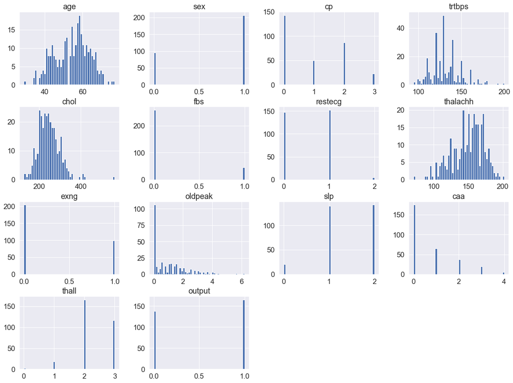

```python
### EDA stars here
df = pd.read_csv('./heart.csv')

df.hist(bins=50, figsize=(20,15))
plt.show()
```

```python
dumm = pd.get_dummies(df.output)
newdf = df.join(dumm)
corr = newdf.corr()
corr.style.background_gradient(cmap='coolwarm')
```

|  | age | sex | cp | trtbps | chol | fbs | restecg | thalachh | exng | oldpeak | slp | caa | thall | output | 0 | 1 |
| --- | --- | --- | --- | --- | --- | --- | --- | --- | --- | --- | --- | --- | --- | --- | --- | --- |
| age | 1.000000 | -0.098447 | -0.068653 | 0.279351 | 0.213678 | 0.121308 | -0.116211 | -0.398522 | 0.096801 | 0.210013 | -0.168814 | 0.276326 | 0.068001 | -0.225439 | 0.225439 | -0.225439 |
| sex | -0.098447 | 1.000000 | -0.049353 | -0.056769 | -0.197912 | 0.045032 | -0.058196 | -0.044020 | 0.141664 | 0.096093 | -0.030711 | 0.118261 | 0.210041 | -0.280937 | 0.280937 | -0.280937 |
| cp | -0.068653 | -0.049353 | 1.000000 | 0.047608 | -0.076904 | 0.094444 | 0.044421 | 0.295762 | -0.394280 | -0.149230 | 0.119717 | -0.181053 | -0.161736 | 0.433798 | -0.433798 | 0.433798 |
| trtbps | 0.279351 | -0.056769 | 0.047608 | 1.000000 | 0.123174 | 0.177531 | -0.114103 | -0.046698 | 0.067616 | 0.193216 | -0.121475 | 0.101389 | 0.062210 | -0.144931 | 0.144931 | -0.144931 |
| chol | 0.213678 | -0.197912 | -0.076904 | 0.123174 | 1.000000 | 0.013294 | -0.151040 | -0.009940 | 0.067023 | 0.053952 | -0.004038 | 0.070511 | 0.098803 | -0.085239 | 0.085239 | -0.085239 |
| fbs | 0.121308 | 0.045032 | 0.094444 | 0.177531 | 0.013294 | 1.000000 | -0.084189 | -0.008567 | 0.025665 | 0.005747 | -0.059894 | 0.137979 | -0.032019 | -0.028046 | 0.028046 | -0.028046 |
| restecg | -0.116211 | -0.058196 | 0.044421 | -0.114103 | -0.151040 | -0.084189 | 1.000000 | 0.044123 | -0.070733 | -0.058770 | 0.093045 | -0.072042 | -0.011981 | 0.137230 | -0.137230 | 0.137230 |
| thalachh | -0.398522 | -0.044020 | 0.295762 | -0.046698 | -0.009940 | -0.008567 | 0.044123 | 1.000000 | -0.378812 | -0.344187 | 0.386784 | -0.213177 | -0.096439 | 0.421741 | -0.421741 | 0.421741 |
| exng | 0.096801 | 0.141664 | -0.394280 | 0.067616 | 0.067023 | 0.025665 | -0.070733 | -0.378812 | 1.000000 | 0.288223 | -0.257748 | 0.115739 | 0.206754 | -0.436757 | 0.436757 | -0.436757 |
| oldpeak | 0.210013 | 0.096093 | -0.149230 | 0.193216 | 0.053952 | 0.005747 | -0.058770 | -0.344187 | 0.288223 | 1.000000 | -0.577537 | 0.222682 | 0.210244 | -0.430696 | 0.430696 | -0.430696 |
| slp | -0.168814 | -0.030711 | 0.119717 | -0.121475 | -0.004038 | -0.059894 | 0.093045 | 0.386784 | -0.257748 | -0.577537 | 1.000000 | -0.080155 | -0.104764 | 0.345877 | -0.345877 | 0.345877 |
| caa | 0.276326 | 0.118261 | -0.181053 | 0.101389 | 0.070511 | 0.137979 | -0.072042 | -0.213177 | 0.115739 | 0.222682 | -0.080155 | 1.000000 | 0.151832 | -0.391724 | 0.391724 | -0.391724 |
| thall | 0.068001 | 0.210041 | -0.161736 | 0.062210 | 0.098803 | -0.032019 | -0.011981 | -0.096439 | 0.206754 | 0.210244 | -0.104764 | 0.151832 | 1.000000 | -0.344029 | 0.344029 | -0.344029 |
| output | -0.225439 | -0.280937 | 0.433798 | -0.144931 | -0.085239 | -0.028046 | 0.137230 | 0.421741 | -0.436757 | -0.430696 | 0.345877 | -0.391724 | -0.344029 | 1.000000 | -1.000000 | 1.000000 |
| 0 | 0.225439 | 0.280937 | -0.433798 | 0.144931 | 0.085239 | 0.028046 | -0.137230 | -0.421741 | 0.436757 | 0.430696 | -0.345877 | 0.391724 | 0.344029 | -1.000000 | 1.000000 | -1.000000 |
| 1 | -0.225439 | -0.280937 | 0.433798 | -0.144931 | -0.085239 | -0.028046 | 0.137230 | 0.421741 | -0.436757 | -0.430696 | 0.345877 | -0.391724 | -0.344029 | 1.000000 | -1.000000 | 1.000000 |

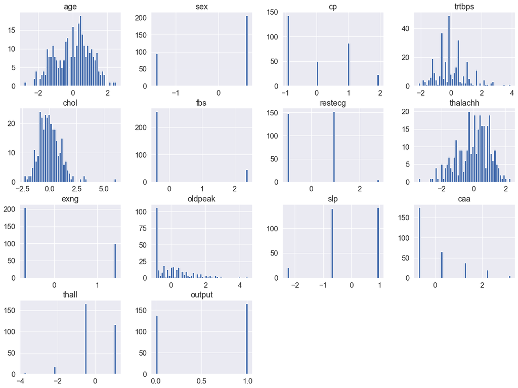

```python
### Pre-processing starts here
from sklearn.preprocessing import StandardScaler
n_df = df[['age', 'sex', 'cp', 'trtbps', 'chol', 'fbs', 'restecg', 'thalachh', 'exng', 'oldpeak', 'slp', 'caa', 'thall']]
scaler = StandardScaler()
scale = scaler.fit_transform(n_df)
n_df = DataFrame(scale, columns=['age', 'sex', 'cp', 'trtbps', 'chol', 'fbs', 'restecg', 'thalachh', 'exng', 'oldpeak', 'slp', 'caa', 'thall'])
n_df['output'] = df['output']
df = n_df
#f_df['output'] = df['output']
df.hist(bins=50, figsize=(20,15))
plt.show()
```

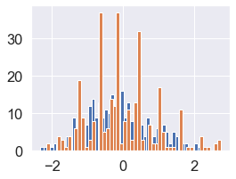

```python
mean = df['chol'].mean()
t_df = df
t_df['chol'] = np.where((df.chol > 2.5),mean,df.chol)

t_df['chol'].hist(bins=50, figsize=(4,3))

mean = df['trtbps'].mean()
t_df['trtbps'] = np.where((df.trtbps > 3),mean,df.trtbps)

t_df['trtbps'].hist(bins=50, figsize=(4,3))
plt.show()
```

```python
t_df = df.drop(['oldpeak'], axis=1)
t_df.head(5)
```

|  | age | sex | cp | trtbps | chol | fbs | restecg | thalachh | exng | slp | caa | thall | output |
| --- | --- | --- | --- | --- | --- | --- | --- | --- | --- | --- | --- | --- | --- |
| 0 | 0.952197 | 0.681005 | 1.973123 | 0.763956 | -0.256334 | 2.394438 | -1.005832 | 0.015443 | -0.696631 | -2.274579 | -0.714429 | -2.148873 | 1 |
| 1 | -1.915313 | 0.681005 | 1.002577 | -0.092738 | 0.072199 | -0.417635 | 0.898962 | 1.633471 | -0.696631 | -2.274579 | -0.714429 | -0.512922 | 1 |
| 2 | -1.474158 | -1.468418 | 0.032031 | -0.092738 | -0.816773 | -0.417635 | -1.005832 | 0.977514 | -0.696631 | 0.976352 | -0.714429 | -0.512922 | 1 |
| 3 | 0.180175 | 0.681005 | 0.032031 | -0.663867 | -0.198357 | -0.417635 | 0.898962 | 1.239897 | -0.696631 | 0.976352 | -0.714429 | -0.512922 | 1 |
| 4 | 0.290464 | -1.468418 | -0.938515 | -0.663867 | 2.082050 | -0.417635 | 0.898962 | 0.583939 | 1.435481 | 0.976352 | -0.714429 | -0.512922 | 1 |

Removing 'oldpeak' make model behave worse, so it is not included

Overall non-categorical data is normally distributed except for oldpeak which is very heavily skewed right. When removing outliers, it tended to make models behave worse.

2-e. Use ML LDA, Perceptron, and LogisticRegression from sklearn to classify the trained data and report the accuracy. [10 pts]

```python
from sklearn.linear_model import LogisticRegression
from sklearn.discriminant_analysis import LinearDiscriminantAnalysis
from sklearn.linear_model import Perceptron
```

```python
### LDA starts here
clf1= LinearDiscriminantAnalysis()
columns = ['age', 'sex', 'cp', 'trtbps', 'chol', 'fbs', 'restecg', 'thalachh', 'exng', 'oldpeak', 'slp', 'caa', 'thall', 'output']
X = df.iloc[:,0:-1]
y = df.iloc[:,-1]

clf1.fit_transform(X,y)
y_pred = clf1.predict(X)
clf1_accuracy = accuracy_score(y,y_pred)
clf1_accuracy
```

```
0.8382838283828383
```

```python
### Perceptron starts here
clf2 = Perceptron(eta0=0.5, random_state=1,max_iter=1000)

X = df.iloc[:,0:-1]
y = df.iloc[:,-1]

clf2.fit(X,y)
y_pred = clf2.predict(X)
clf2_accuracy = accuracy_score(y,y_pred)
clf2_accuracy
```

```
0.7986798679867987
```

```python
### Logistic Regression starts here
clf3 = LogisticRegression()
X = df.iloc[:,0:-1]
y = df.iloc[:,-1]
clf3.fit(X,y)
y_pred = clf3.predict(X)
clf3_accuracy = accuracy_score(y,y_pred)
clf3_accuracy
```

```
0.8481848184818482
```

2-f. Use the implemented classifiers from 2-a to 2-c and classify the output. [10 pts]

```python
y_pred = my_LDA(df)

clf4_accuracy = accuracy_score(y,y_pred)
clf4_accuracy
```

```
0.7821782178217822
```

```python
y_pred = my_Perceptron(df, .5, 1000)

clf5_accuracy = accuracy_score(y,y_pred)
clf5_accuracy
```

```
0.8151815181518152
```

```python
clf6= my_LogisticRegression(df,.5,1000)

clf6_accuracy = accuracy_score(y,y_pred)
clf6_accuracy
```

[output not shown]

```
0.8151815181518152
```

```python
result_table = pd.DataFrame({'Model':['clf1','clf2','clf3','clf4','clf5','clf6'],
                             'Accuracy':[clf1_accuracy,clf2_accuracy,clf3_accuracy,
                                        clf4_accuracy,clf5_accuracy,clf6_accuracy]})
result_table
```

|  | Model | Accuracy |
| --- | --- | --- |
| 0 | clf1 | 0.838284 |
| 1 | clf2 | 0.798680 |
| 2 | clf3 | 0.848185 |
| 3 | clf4 | 0.782178 |
| 4 | clf5 | 0.815182 |
| 5 | clf6 | 0.815182 |